# Lecture Code: ANOVA Conditions

Engineering Statistics I (MA223)

Dr. Reyes

While the “Coding Cookbook” on the course site gives an overview of all code covered in the class, this document provides the code that accompanies the lecture centering on assessing ANOVA conditions.

## Background

The use of threaded nails has expanded into wood construction because they are believed to have superior performance. However, few tests have been conducted on large nails (3.76 mm diameter and larger). Of particular interest is the amount of force required to pull a nail out of a piece of lumber, known as the withdrawal strength. It is unclear if the type of threading affects the strength of larger nails. The *Journal of Structural Engineering* (2001) reported a study conducted to compare the withdrawal strength of three types of nails — annularly threaded, helically threaded, and smooth. Specifically, investigators were interested in determining if, on average, the withdrawal strength differed among the three types of large nails. The full citation is provided below:

> Rammer DR, Winistorfer SG, and Bender DA. “Withdrawal strength of threaded nails.” *Journal of Structural Engineering*. (2001) 127(4):442-449.

In brief, a sample of 150 nails with a nominal diameter of 3.76 mm (or as close to this as possible) was obtained. Investigators selected 50 nails which were annularly threaded, 50 which were helically threaded, and 50 which were smooth. Each nail was de-greased in a trichloroethane 1-1-1 bath for a minimum of 20 minutes and then air dried for a minimum of 1 hour before being driven into a specimen of Spruce-Pine-Fir. All lumber was conditioned at 20 degrees C and 80% relative humidity for several months. Each nail was driven into the lumber to a depth of 70% of the nail length or thread length, whichever was shorter. No pilot holes were drilled.

The first few records of the data are shown below.

```
# A tibble: 150 x 2
   Withdrawal_Strength Threading
                 <dbl>     <chr>
 1            46.15115   Annular
 2            53.58642   Annular
 3            41.18614   Annular
 4            45.99234   Annular
 5            50.71735   Annular
 6            63.46379   Annular
 7            22.43583   Annular
 8            51.76276   Annular
 9            55.44089   Annular
10            44.09509   Annular
# ... with 140 more rows
```

## Model

In order to examine our question of interest, which has the form
$$H_0: \mu_1 = \mu_2 = \mu_3 \quad \text{vs.} \quad H_1: \text{at least one mean differs}$$

where $\mu_1$, $\mu_2$ and $\mu_3$ represent the mean withdrawal strength for each type of threaded nail (annular, helical, and smooth, respectively), we need to model the the process which led to the responses we have observed. In this case, we consider the following model:

$$\begin{aligned}
(\text{Withdrawal Strength})_i &= \mu_1 \mathbb{I}(\text{i-th nail has annular threading}) + \mu_2 \mathbb{I}(\text{i-th nail has helical threading}) \\
&\quad + \mathbb{I}(\text{i-th nail has smooth threading}) + \epsilon_i
\end{aligned}$$

Notice this model allows each group to have its own mean (potentially). In order to compute a p-value, we use this model to construct a model for the null distribution of our standardized test statistic. The issue is that we could model the null distribution in one of three ways, each depending on the conditions we are willing to assume.

The classical ANOVA model places the following conditions on the error term:

- The error in the withdrawal strength for one nail is independent of the error in the withdrawal strength for any other nail.
- The variability of the errors in the withdrawal strength is the same for each of the three threading types.
- The errors follow a Normal distribution.

Under these conditions, we can form an analytical model for the null distribution.

If we are only willing to assume two of those conditions are met, then we can use bootstrapping to model the null distribution:

- The error in the withdrawal strength for one nail is independent of the error in the withdrawal strength for any other nail.
- The variability of the errors in the withdrawal strength is the same for each of the three threading types.

Similarly, it turns out a different bootstrapping algorithm can be used to model the null distribution empirically under only the following condition:

- The error in the withdrawal strength for one nail is independent of the error in the withdrawal strength for any other nail.

The question is, which of the three models is most appropriate? To address this, we assess each of the conditions in turn.

## Residuals

Residuals are used to assess conditions. In order to obtain the residuals, we need to use the following code:

```r
> fit.nails.h1 <- lm(Withdrawal_Strength ~ Threading, data = nails)
>
> nails.diag <- augment(fit.nails.h1)
```

This “augmented” dataset contains the original data used in the model alongside the residuals.

## Normality

To assess Normality, we construct a probability plot:

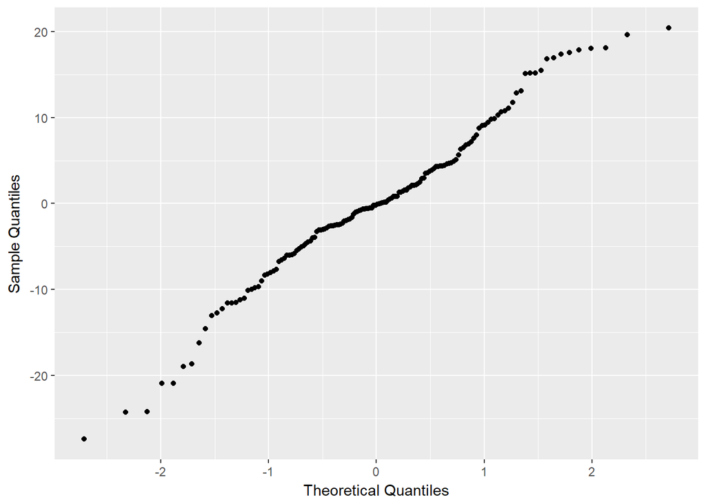

```r
> qplot(data = nails.diag,
+       sample = .resid,
+       geom = "qq",
+       xlab = "Theoretical Quantiles",
+       ylab = "Sample Quantiles")
```

## Constant Variance

To assess whether the variability of the errors is constant, we actually examine the spread of the response within each group. In order to do that, we look at the side-by-side boxplot of the response.

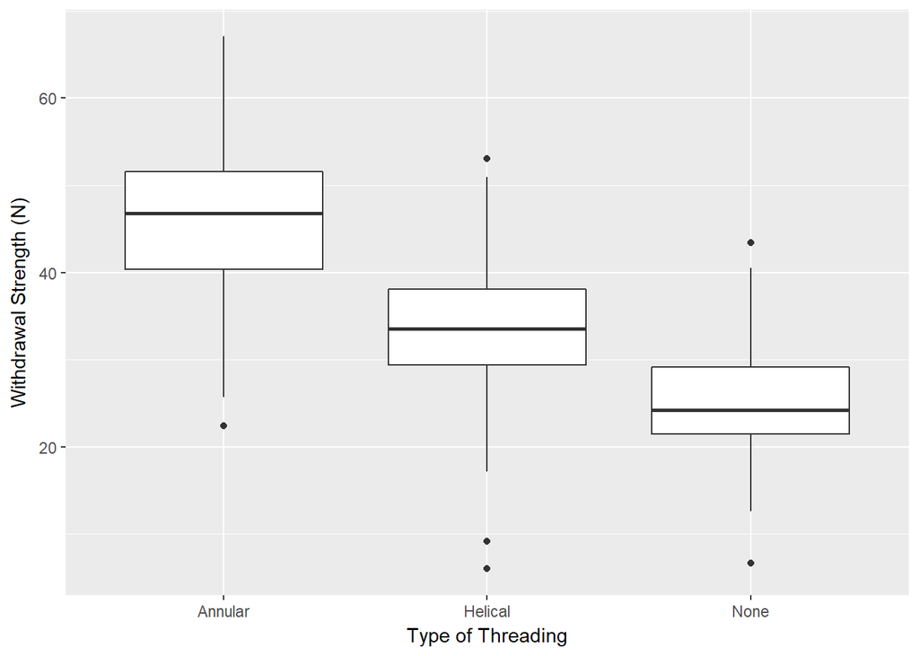

```r
> qplot(data = nails,
+       x = Threading,
+       y = Withdrawal_Strength,
+       geom = "boxplot",
+       xlab = "Type of Threading",
+       ylab = "Withdrawal Strength (N)")
```

If the data is consistent with this condition, then the interquartile range should be the same for each of the three groups, roughly.

## Independence

*If the order in which the data was collected* is known, we can construct a time-series plot of the residuals:

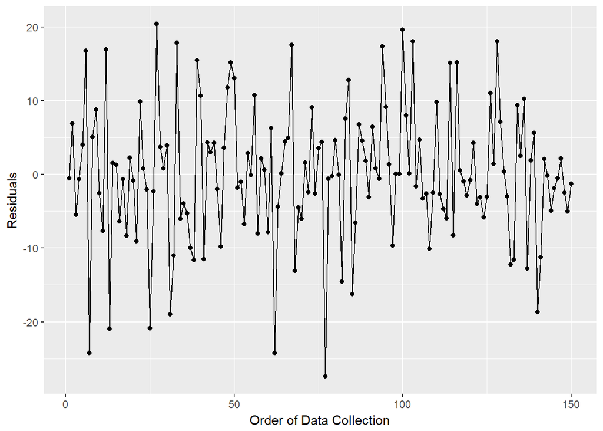

```r
> qplot(data = nails.diag,
+       x = seq_along(.resid),
+       y = .resid,
+       geom = c("line", "point"),
+       xlab = "Order of Data Collection",
+       ylab = "Residuals")
```

However, *in this case, the order is unknown*; therefore, the above plot is not helpful. Instead we must rely solely on the method in which the data was collected to determine if there is anything that might suggest a relationship among the responses.